# 线性回归的算法

```python
import platform
import datetime
import sys
import os


your_name, your_code, work_counter = "杜培博", 200507340136, 4
print(f'我是：{your_name}，学号：{your_code}，这是我的第 {work_counter} 次作业。')
print('现在是', datetime.datetime.now())
print('我的机器信息如下：')
print(platform.uname())

print('\n当前工作目录：')
print(os.getcwd())
print('\n当前目录的文件信息如下：')
print(os.listdir())
print('\n我安装包的情况:')
!pip list
```

[output not shown]

[output cut: 66 more lines]

[output not shown]

[output not shown]

[output not shown]

# 1 用简洁实现的模式，自行实现线性回归的算法过程

```python
import torch
import random
import numpy as np
import torch.nn as nn
import torch.optim as optim
import torch.utils.data as Data
```

```python
np.random.seed(2022)
feature = np.random.normal(0,1,(100,2))
feature = torch.from_numpy(feature).to(torch.float32)   # 默认是float64，会报错，需改一下
# feature.to(feature.float32)
label = feature[:,0]*2.5+feature[:,1]*5.2+3   # 定义的w=[2.5,5.2],b=3
label.dtype
```

```
torch.float32
```

```python
# 将数据进行工业化封装
batch_size = 3
dataset = Data.TensorDataset(feature,label)
data_iter = Data.DataLoader(dataset,batch_size,shuffle = True)
```

```python
# 定义我们的全连接神经网络
class LinearNet(nn.Module):
    def __init__(self,feature):
        super(LinearNet,self).__init__()
        self.linear = nn.Linear(feature,1)

    def forward(self,x):
        y = self.linear(x)
        return y
net = LinearNet(2)
net
```

```
LinearNet(
  (linear): Linear(in_features=2, out_features=1, bias=True)
)
```

```python
# 这里使用的是模型随机初始化的参数
for param in net.parameters():
    print(param)
```

```
Parameter containing:
tensor([[-0.4110, -0.0767]], requires_grad=True)
Parameter containing:
tensor([-0.3106], requires_grad=True)
```

```python
loss = nn.MSELoss()   # 采用的MSE损失
```

```python
optimizer = optim.SGD(net.parameters(),lr=0.01)
optimizer
```

```
SGD (
Parameter Group 0
    dampening: 0
    lr: 0.01
    momentum: 0
    nesterov: False
    weight_decay: 0
)
```

```python
num_epoth = 10
for epoth in range(1,num_epoth+1):
    for i,j in data_iter:
#         print(i)
        # 计算网络输出
        output = net(i)
        l = loss(output, j.view(-1, 1))
        # 先梯度清零，再求梯度
        optimizer.zero_grad()
        l.backward()
        optimizer.step()
    print('epoth %d, loss: %f' % (epoth, l.item()))
```

```
epoth 1, loss: 1.444914
epoth 2, loss: 0.026037
epoth 3, loss: 0.005927
epoth 4, loss: 0.191373
epoth 5, loss: 0.049743
epoth 6, loss: 0.011667
epoth 7, loss: 0.001170
epoth 8, loss: 0.000297
epoth 9, loss: 0.000001
epoth 10, loss: 0.000112
```

```python
for param in net.parameters():
    print(param)     # 此时与定义的w=[2.5,5.2],b=3参数非常相近
```

```
Parameter containing:
tensor([[2.4852, 5.1942]], requires_grad=True)
Parameter containing:
tensor([2.9973], requires_grad=True)
```

# 2 工业化封装

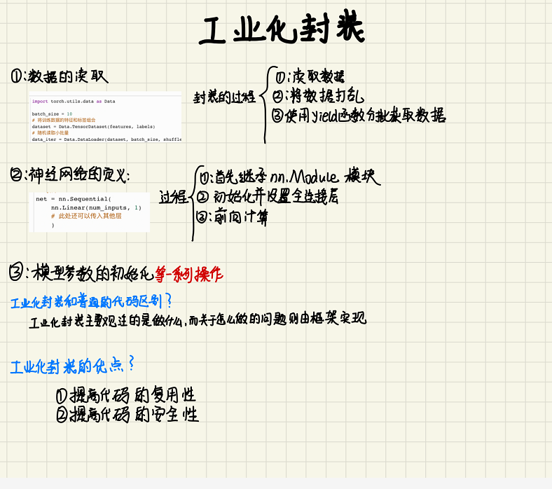

# 3 自学菜鸟 Linux 教程的

### Linux 系统目录结构:输入ls /列出根目录下的所有目录

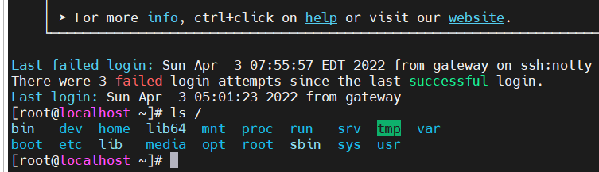

基本的结构状况：

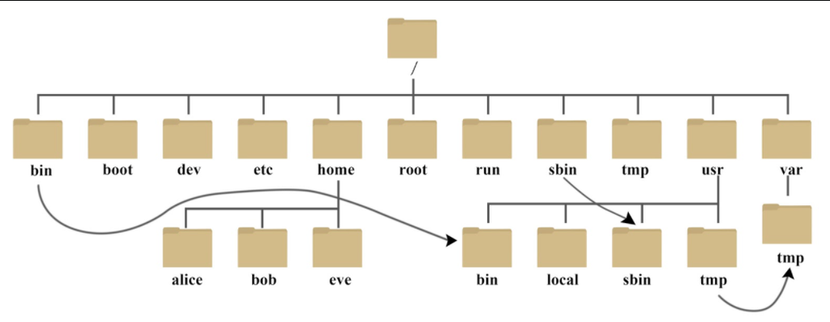

几个重要的文件夹：

```
    ·boot：这里存放的是启动 Linux 时使用的一些核心文件，包括一些连接文件以及镜像文件
    ·etc：这个目录用来存放所有的系统管理所需要的配置文件和子目录
    ·root：该目录为系统管理员，也称作超级权限者的用户主目录
    ·usr:这是一个非常重要的目录，用户的很多应用程序和文件都放在这个目录下，类似于 windows 下的 program             files 目录。
```

### Linux 文件与目录管理

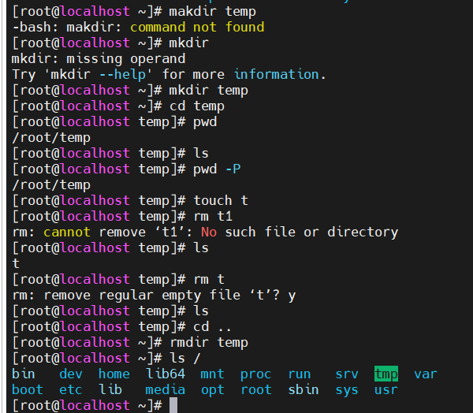

常用的命令：

```
    ·ls（英文全拼：list files）: 列出目录及文件名
    ·cd（英文全拼：change directory）：切换目录
    ·pwd（英文全拼：print work directory）：显示目前的目录
    ·mkdir（英文全拼：make directory）：创建一个新的目录
    ·rmdir（英文全拼：remove directory）：删除一个空的目录
    ·cp（英文全拼：copy file）: 复制文件或目录
    ·rm（英文全拼：remove）: 删除文件或目录
    ·mv（英文全拼：move file）: 移动文件与目录，或修改文件与目录的名称
```

### Linux vi/vim

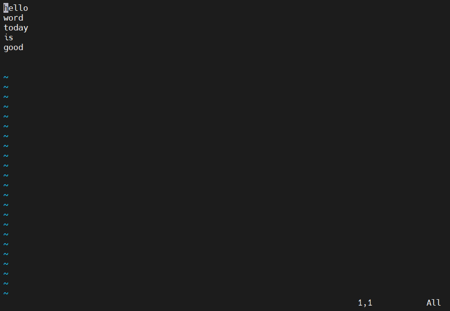

#### 功能键

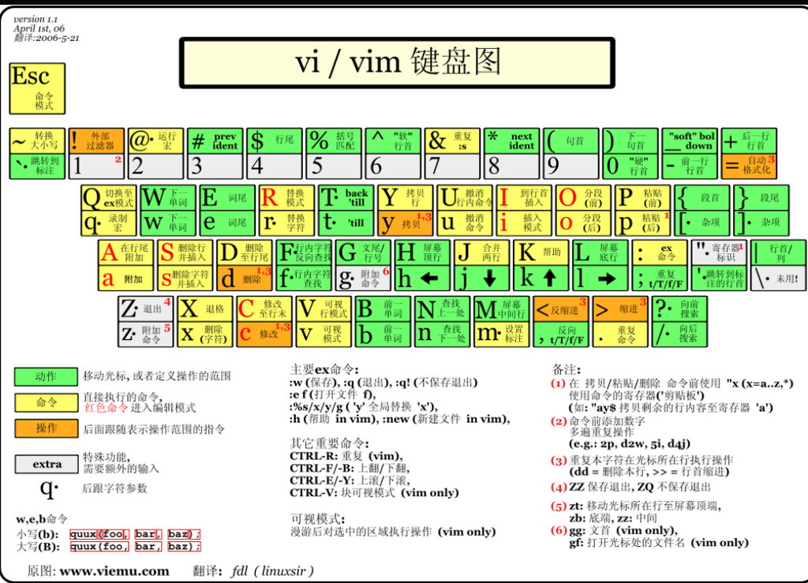

### Linux yum 命令：基于 RPM 包管理，能够从指定的服务器自动下载 RPM 包并且安装，可以自动处理依赖性关系，并且一次安装所有依赖的软件包，无须繁琐地一次次下载、安装。yum 提供了查找、安装、删除某一个、一组甚至全部软件包的命令，而且命令简洁而又好记

yum常用命令

1. 列出所有可更新的软件清单命令：yum check-update
2. 更新所有软件命令：yum update
3. 仅安装指定的软件命令：yum install
4. 仅更新指定的软件命令：yum update
5. 列出所有可安裝的软件清单命令：yum list
6. 删除软件包命令：yum remove
7. 查找软件包命令：yum search
8. 清除缓存命令:

yum clean packages: 清除缓存目录下的软件包

yum clean headers: 清除缓存目录下的 headers

yum clean oldheaders: 清除缓存目录下旧的 headers

yum clean, yum clean all (= yum clean packages; yum clean oldheaders) :清除缓存目录下的软件包及旧的 headers

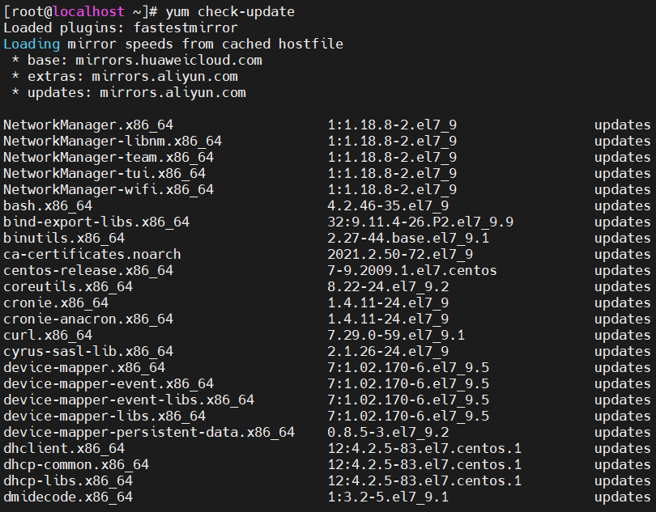

更换源

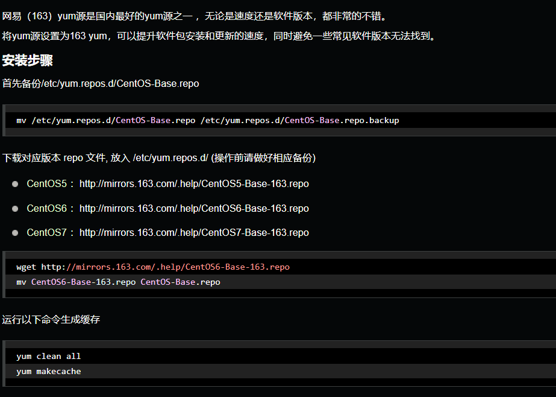